# fitly_churn_analysis

Munem Shariar Shams

2026-01-06

# Fit.ly Churn Analysis

## 1. Data Validation

### 1.1 Account Information

Columns: `customer_id`, `email`, `state`, `plan`, `plan_list_price`, `churn_status`

- No missing customer IDs
- 400 unique customers
- Converted customer IDs to numeric `user_id`
- All plans valid: Free, Basic, Pro, Enterprise

### 1.2 Customer Support

- Valid timestamps for all support tickets
- Resolution times range from **0.5 to ~32 hours**
- Channels include email, phone, and chat

### 1.3 User Activity

- Valid event timestamps
- Event types include watch_video, read_article, track_workout, share_workout

Derived features:

- `event_count` per user
- `engagement_bucket` (0, 1, 2, 3+ events)

# Load Libraries

```r
library(tidyverse)
library(lubridate)
library(scales)
```

# Load Data

```r
acct <- read_csv("da_fitly_account_info.csv")
supp <- read_csv("da_fitly_customer_support.csv")
act  <- read_csv("da_fitly_user_activity.csv")
```

# Clean and Prepare Account Data

```r
acct <- acct %>%
  mutate(
    churn_status = trimws(churn_status),
    churn_status = if_else(churn_status == "" | is.na(churn_status), "N", churn_status),
    churn_status = toupper(churn_status),
    user_id = as.integer(sub("C", "", customer_id)),
    is_churn = churn_status == "Y"
  )
```

# Clean Customer Support Data

```r
supp <- supp %>%
  mutate(
    ticket_time = ymd_hms(ticket_time),
    resolution_time_hours = as.numeric(resolution_time_hours),
    user_id = as.integer(user_id)
  )
```

# Clean User Activity Data

```r
act <- act %>%
  mutate(
    event_time = ymd_hms(event_time),
    user_id = as.integer(user_id)
  )
```

# Feature Engineering

## Event Counts

```r
event_counts <- act %>%
  group_by(user_id) %>%
  summarise(event_count = n(), .groups = "drop")

acct <- acct %>%
  left_join(event_counts, by = "user_id") %>%
  mutate(
    event_count = if_else(is.na(event_count), 0L, event_count),
    engagement_bucket = case_when(
      event_count == 0 ~ "0 events",
      event_count == 1 ~ "1 event",
      event_count == 2 ~ "2 events",
      TRUE ~ "3+ events"
    )
  )
```

## Support Ticket Counts

```r
ticket_counts <- supp %>%
  group_by(user_id) %>%
  summarise(ticket_count = n(), .groups = "drop")

acct <- acct %>%
  left_join(ticket_counts, by = "user_id") %>%
  mutate(ticket_count = if_else(is.na(ticket_count), 0L, ticket_count))
```

## Ticket Groups

```r
acct <- acct %>%
  mutate(ticket_group = case_when(
    ticket_count == 0 ~ "0 tickets",
    ticket_count == 1 ~ "1 ticket",
    ticket_count <= 3 ~ "2–3 tickets",
    TRUE ~ "4+ tickets"
  ))
```

# Compute Metrics

```r
overall_churn <- mean(acct$is_churn)

churn_by_plan <- acct %>%
  group_by(plan) %>%
  summarise(churn_rate = mean(is_churn))

churn_by_engagement <- acct %>%
  group_by(engagement_bucket) %>%
  summarise(churn_rate = mean(is_churn))

churn_by_tickets <- acct %>%
  group_by(ticket_group) %>%
  summarise(churn_rate = mean(is_churn))

overall_churn
```

```
## [1] 0.285
```

```r
churn_by_plan
```

```
## # A tibble: 4 × 2
##   plan       churn_rate
##   <chr>           <dbl>
## 1 Basic           0.237
## 2 Enterprise      0.261
## 3 Free            0.410
## 4 Pro             0.224
```

```r
churn_by_engagement
```

```
## # A tibble: 4 × 2
##   engagement_bucket churn_rate
##   <chr>                  <dbl>
## 1 0 events              0.539
## 2 1 event               0.214
## 3 2 events              0.0581
## 4 3+ events             0.0417
```

```r
churn_by_tickets
```

```
## # A tibble: 4 × 2
##   ticket_group churn_rate
##   <chr>             <dbl>
## 1 0 tickets         0.152
## 2 1 ticket          0.286
## 3 2–3 tickets       0.306
## 4 4+ tickets        0.289
```

# Exploratory Analysis

## Customer Count by Plan

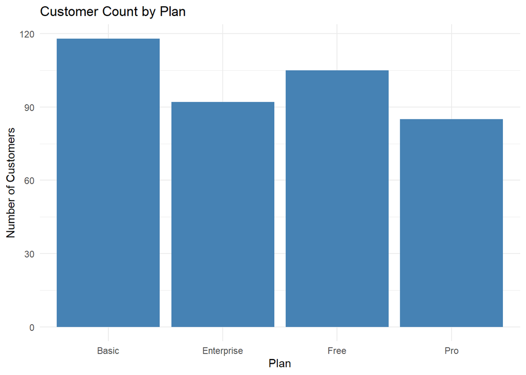

```r
ggplot(acct, aes(x = plan)) +
  geom_bar(fill = "steelblue") +
  labs(
    title = "Customer Count by Plan",
    x = "Plan",
    y = "Number of Customers"
  ) +
  theme_minimal()
```

## Distribution of Support Resolution Time

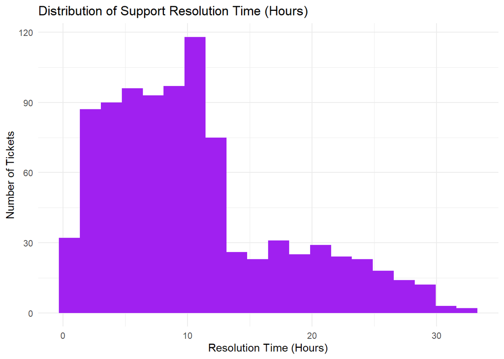

```r
ggplot(supp, aes(x = resolution_time_hours)) +
  geom_histogram(fill = "purple", bins = 20) +
  labs(
    title = "Distribution of Support Resolution Time (Hours)",
    x = "Resolution Time (Hours)",
    y = "Number of Tickets"
  ) +
  theme_minimal()
```

## Churn Rate by Engagement Bucket

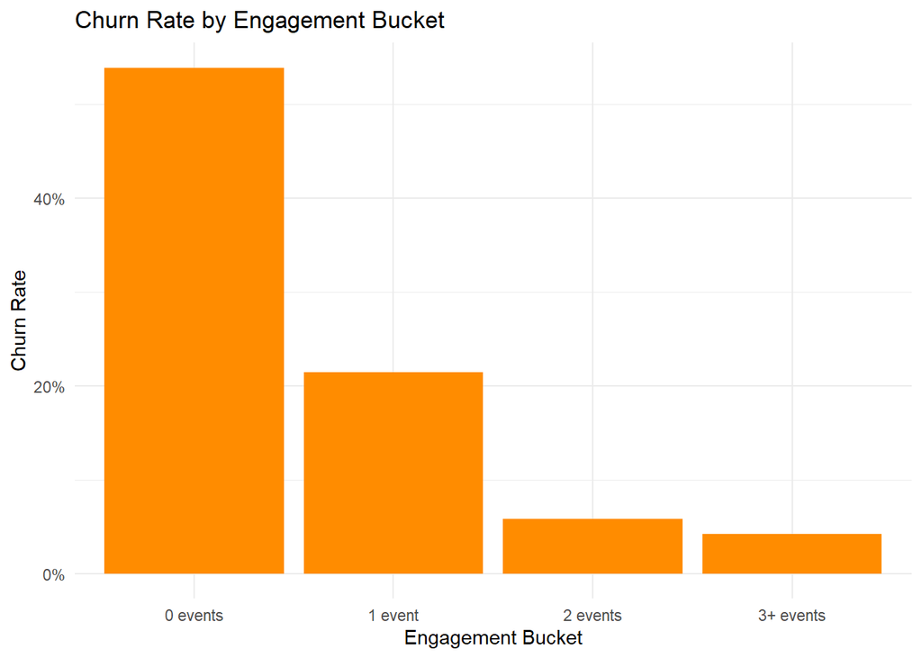

```r
eng_churn <- acct %>%
  group_by(engagement_bucket) %>%
  summarise(churn_rate = mean(is_churn)) %>%
  mutate(
    engagement_bucket = factor(
      engagement_bucket,
      levels = c("0 events", "1 event", "2 events", "3+ events")
    )
  )

ggplot(eng_churn, aes(x = engagement_bucket, y = churn_rate)) +
  geom_col(fill = "darkorange") +
  labs(
    title = "Churn Rate by Engagement Bucket",
    x = "Engagement Bucket",
    y = "Churn Rate"
  ) +
  scale_y_continuous(labels = percent_format()) +
  theme_minimal()
```

# Key Insights

- Overall churn rate is approximately **28.5%**
- **Free plan users churn the most**
- **Customer engagement strongly reduces churn**
- Users with **0 events churn over 50% of the time**
- Customers who contact **support churn roughly twice as often**

# Recommended Business Metric

**Monthly Churn Rate**

Track churn by:

- Plan type
- Engagement bucket
- Support ticket volume

# Recommendations

- Improve **early user engagement**
- Encourage **at least two meaningful product events**
- Reduce **support resolution times**
- Improve **free-tier onboarding**
- Monitor churn trends monthly